# Introduction to `SimulationStudy` Package

In this document, we illustrate the R package `SimulationStudy` (https://github.com/tianyi-pan/simulationstudy-package) for simulation study of sampling distributions of trimmed and untrimmed means.

```r
# install.packages('devtools')
# devtools::install_github('tianyi-pan/simulationstudy-package')
library(simulationstudy)
```

# Description of `SimulationStudy` Package

Trimmed mean is an important robust estimator which is less sensitive to the possible outliers in the sample that might come from contamination rather than the population of interest (Kimber 1983). The trimmed mean for exponential distribution has been investigated when there is contamination in the sample populationWillemain et al. (1992). We focus on the cost of the robust estimator when there is no contamination.

The package `simulationstudy` was designed to investigate the cost of trimmed mean in terms of efficiency in estimating population mean when there is no contamination.

Following Morris et al. (2019), the simulation study can be summarized in the following ADEMP structure,

- Aim: investigate the cost of trimmed mean in terms of efficiency in estimating population mean when there is no contamination.
- Data-generating mechanism: $X_1, \cdots, X_n \sim \mathrm{EXP}(\lambda)$, where $\mathrm{EXP}(\lambda)$ represents the exponential distribution with rate parameter $\lambda$.
- Estimand: Sampling distribution of trimmed/untrimmed mean.
- Method: 1) Trimmed mean and 2) Untrimmed mean.
- Performance measure: 1) Bias and 2) Standard Error (SE)

In this `simulationstudy` package, we provide functions for running the simulation, and summarizing results in figures and tables. We will introduce the functions in the package, and then discuss the programming checking.

# An example for SimulationStudy Package

We will describe how to use the package through an example with the following choice of levels:

## Main function

The main function of the package is `simulation()`. The function contains the following arguments,

- `lambda.all`: A vector of the rate parameters of the Exponential distribution.
- `n.all`: A vector of sample sizes.
- `trim.prop.all`: A vector of proportions of trimming.
- `Nsim`: Number of simulations.
- `seed`: Seed for random number generator.

In this example, we set the following vector for the level of parameters,

```r
## rate parameter in exponential distribution
lambda.all = c(0.5, 1, 2)
## sample size
n.all = c(5, 10, 20, 30, 40, 50, 100, 200, 300)
## propotion of trimming
trim.prop.all = c(0, 0.1, 0.2, 0.5)
```

Then, we pass the arguments into the function `simulation()`, and set the number of repetition `Nsim` as 8000.

```r
sim_results <- simulation(lambda.all = lambda.all,
                          n.all = n.all,
                          trim.prop.all = trim.prop.all,
                          Nsim = 8000,
                          seed = 123)
# takes around 10 seconds...
```

In this function, we also claim the random seed for random number generating to ensure the reproducibility of the simulation study. If the argument `Nsim` is missing, the `simulation` function will automatically call the auxiliary function `optimal.Nsim()` to calculate the optimal choice of the number of repetition, controlling the Monte Carlo standard error (Morris et al. 2019) under a specific level, which defaults as $1\%$. In the underlying `optimal.Nsim()` function, the vector of $\lambda$ and the vector of $n$ are passed and it will return the the smallest integer to make sure the Monte Carlo standard error under the specific level (set in argument `MCSE`).

```r
optimal.Nsim(lambda = lambda.all, n = n.all, MCSE = 0.01)
```

```
#> [1] 8000
```

The return of the `simulation` function is an S3 class, which is named as `simtrim`. We can check it by the base function `class()` in R,

```r
class(sim_results)
```

```
#> [1] "simtrim"
```

The following functions for generating tables and figures are all designed as S3 methods for this specific `simtrim` class.

## Example of Constraints and Tests

Function `simulation_means`:

- `lambda`: A postive number
- `n`: A positive integer
- `trim.prop`: A positive number in [0,0.5]
- `Nsim`: A positive integer
- `seed`: Non-negative integer or NULL

For testing, we used the unit test framework of R, `testthat`. You can put your R file for testing in the package’s top-level folder `tests/testthat`. Here is an example of a testing function:

```r
library(testthat)

# Test 1: Test that simulate_means returns an error with negative lambda
test_that("simulate_means throws error with negative lambda", {
  expect_error(simulate_means(lambda = -1, n = 10, trim.prop = 0.2, Nsim = 100), "lambda must be a positive number")
})
```

```
#> Test passed 🥇
```

After setting up all the test cases, simple run `devtools::test()` to run all the unit tests.

## Summarize Results in Tables

Let’s now summarize simulation results in tables. The S3 method for the simulation results is `summary.simtrim`. We could simply call the `summary()` function for the returned `simtrim` object from `simulation()` function. The `summary` function contains the following argument,

- `object`: A list of results from simulation function
- `type`: A character string specifying the type of table, which can be one of “MSE”, “SE” or “Bias”.
- `lambda.select`: A numeric value / vector for lambda if you want to filter results based on specific lambda values. Default is NULL, which indicates all levels are selected
- `trim.prop.select`: A numeric value / vector for trim proportion if you want to filter results based on specific trim proportions. Default is NULL, which indicates all levels are selected.
- `n.select`: A numeric value / vector for sample size if you want to filter results based on specific sample sizes. Default is NULL, which indicates all levels are selected.

The returned data frame contains four columns besides the values of factors:

- `EST.untrimmed`: The estimated value of the untrimmed mean
- `EST.trimmed`: The estimated value of the trimmed mean
- `MCSE.untrimmed`: The MCSE of the untrimmed mean
- `MCSE.trimmed`: The MCSE of the trimmed mean

### Bias

We can set the `type = "Bias"` to generate tables for Bias. We can fix the some factors to check the Bias varying by the other factors. For example, we interested in the cases that $\lambda = 1$ and propotion of trimming is 0.1,

```r
summary(sim_results, lambda.select = 1, trim.prop.select = 0.1, type = "Bias")
```

| n | lambda | trim.prop | EST.untrimmed | EST.trimmed | MCSE.untrimmed | MCSE.trimmed |
| --- | --- | --- | --- | --- | --- | --- |
| 5 | 1 | 0.1 | 0.0024 | 0.0024 | 0.0050 | 0.0050 |
| 10 | 1 | 0.1 | -0.0012 | -0.1297 | 0.0035 | 0.0032 |
| 20 | 1 | 0.1 | -0.0029 | -0.1498 | 0.0025 | 0.0023 |
| 30 | 1 | 0.1 | -0.0023 | -0.1563 | 0.0020 | 0.0018 |
| 40 | 1 | 0.1 | -0.0021 | -0.1594 | 0.0017 | 0.0016 |
| 50 | 1 | 0.1 | -0.0009 | -0.1601 | 0.0016 | 0.0014 |
| 100 | 1 | 0.1 | -0.0003 | -0.1646 | 0.0011 | 0.0010 |
| 200 | 1 | 0.1 | -0.0004 | -0.1670 | 0.0008 | 0.0007 |
| 300 | 1 | 0.1 | -0.0004 | -0.1678 | 0.0006 | 0.0006 |

We can also, for example, fix the sample size $n = 10$, and $trim.prop = 0.1$ or $lambda.select = 1$ to check the Bias varying by the other factor,

```r
summary(sim_results, n.select = 10, trim.prop.select = 0.1, type = "Bias")
```

| n | lambda | trim.prop | EST.untrimmed | EST.trimmed | MCSE.untrimmed | MCSE.trimmed |
| --- | --- | --- | --- | --- | --- | --- |
| 10 | 0.5 | 0.1 | -0.0024 | -0.2595 | 0.0070 | 0.0065 |
| 10 | 1.0 | 0.1 | -0.0012 | -0.1297 | 0.0035 | 0.0032 |
| 10 | 2.0 | 0.1 | -0.0006 | -0.0649 | 0.0017 | 0.0016 |

```r
summary(sim_results, n.select = 10, lambda.select = 1, type = "Bias")
```

| n | lambda | trim.prop | EST.untrimmed | EST.trimmed | MCSE.untrimmed | MCSE.trimmed |
| --- | --- | --- | --- | --- | --- | --- |
| 10 | 1 | 0.0 | -0.0012 | -0.0012 | 0.0035 | 0.0035 |
| 10 | 1 | 0.1 | -0.0012 | -0.1297 | 0.0035 | 0.0032 |
| 10 | 1 | 0.2 | -0.0012 | -0.1961 | 0.0035 | 0.0032 |
| 10 | 1 | 0.5 | -0.0012 | -0.2548 | 0.0035 | 0.0034 |

### Standard Error (SE)

For the tables for standard error, we could simply pass `type = SE` to the `summary` function. The other settings are same as those in the Bias tables.

```r
summary(sim_results, n.select = 10, trim.prop.select = 0.1, type = "SE")
```

| n | lambda | trim.prop | Relative.SE | EST.untrimmed | EST.trimmed | MCSE.untrimmed | MCSE.trimmed |
| --- | --- | --- | --- | --- | --- | --- | --- |
| 10 | 0.5 | 0.1 | 1.0783 | 0.6249 | 0.5795 | 0.0049 | 0.0046 |
| 10 | 1.0 | 0.1 | 1.0783 | 0.3124 | 0.2897 | 0.0025 | 0.0023 |
| 10 | 2.0 | 0.1 | 1.0783 | 0.1562 | 0.1449 | 0.0012 | 0.0011 |

### Mean Square Error (MSE)

Although the MSE is not the main performance measure of this simulation study, we also provide an option for users to report the MSE, simply passing `type = MSE`. The other settings are same as those in the Bias tables.

```r
summary(sim_results, n.select = 10, lambda.select = 1, type = "MSE")
```

| n | lambda | trim.prop | EST.untrimmed | EST.trimmed | MCSE.untrimmed | MCSE.trimmed |
| --- | --- | --- | --- | --- | --- | --- |
| 10 | 1 | 0.0 | 0.0976 | 0.0976 | 0.0017 | 0.0017 |
| 10 | 1 | 0.1 | 0.0976 | 0.1008 | 0.0017 | 0.0014 |
| 10 | 1 | 0.2 | 0.0976 | 0.1205 | 0.0017 | 0.0015 |
| 10 | 1 | 0.5 | 0.0976 | 0.1573 | 0.0018 | 0.0018 |

## Summarize Results in Figures

Beside the tables from `summary` function, we also provide a `plot()` function to visualize the simulation results in Box plots, and line plots in terms of Bias, SE as well as MSE. We also have an option for QQ-plot to compare the sampling distributions of trimmed and untrimmed means.

The S3 method for the simulation results is `plot.simtrim`. We could call the `plot()` function for the returned `simtrim` object from `simulation()` function. The `plot` function contains the following argument,

- `object`: A list of results from simulation function
- `type`: A character string specifying the type of plot. Can be one of “Box”, “MSE”, “SE”, “Bias”, or “qq”.
- `lambda`: A numeric value for lambda if you want to filter results based on a specific lambda value.
- `trim.prop`: A numeric value for trim proportion if you want to filter results based on a specific trim proportion.
- `n`: A numeric value for sample size if you want to filter results based on a specific sample size.
- `...` : Additional arguments for plotting, such as ‘ul’ and ‘ll’ for upper and lower limits for QQ-plot.

Next, we will show the following figures from the `plot` function.

### Box plot

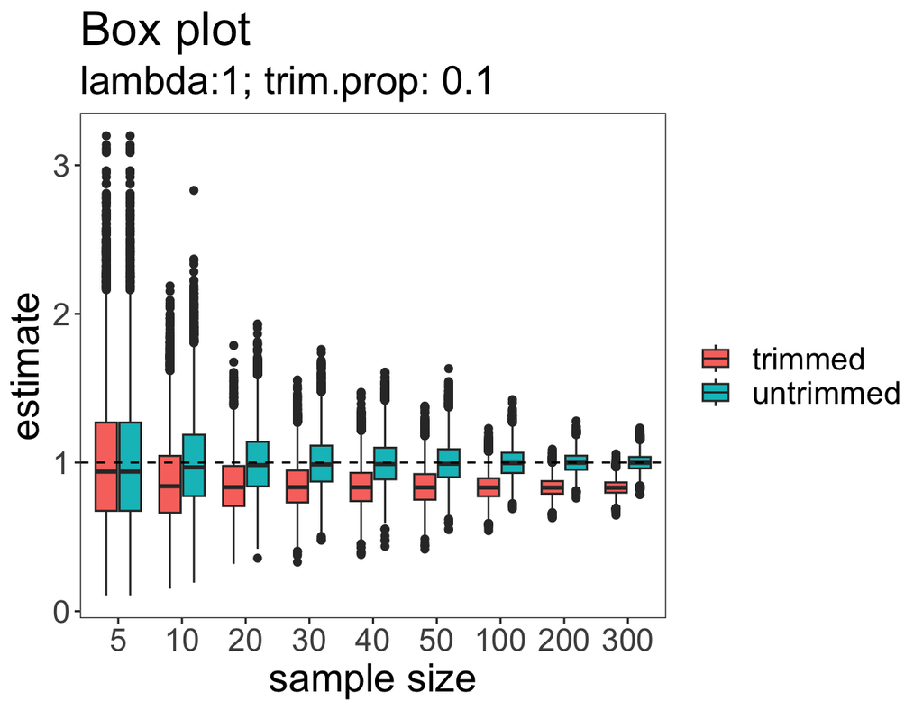

```r
plot(sim_results, type = "Box", lambda = 1, trim.prop = 0.1)
```

The levels of factors depends on the research of interests. For example, if we are interested in properties of 0.5 proportion of trimming (indeed median of the sample), we could set `trim.prop = 0.5`,

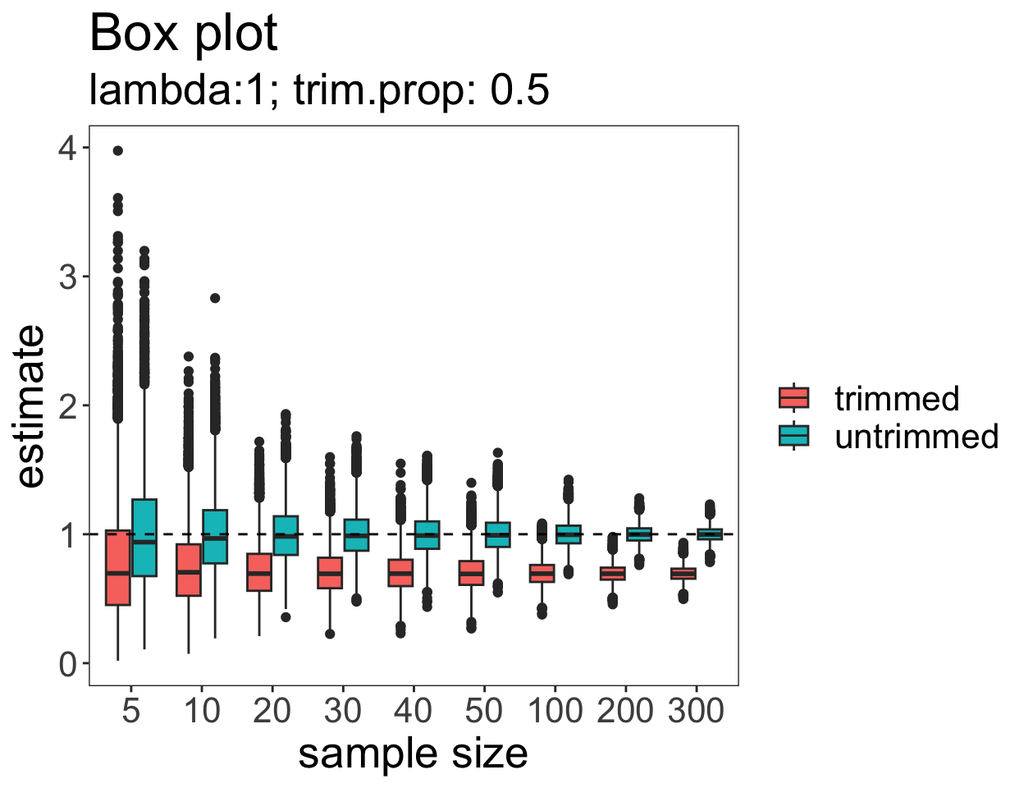

```r
plot(sim_results, type = "Box", lambda = 1, trim.prop = 0.5)
```

### QQ-Plot

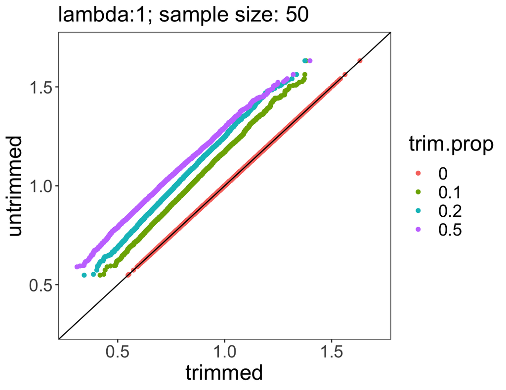

```r
plot(sim_results, type = "qq", lambda = 1, n = 50)
```

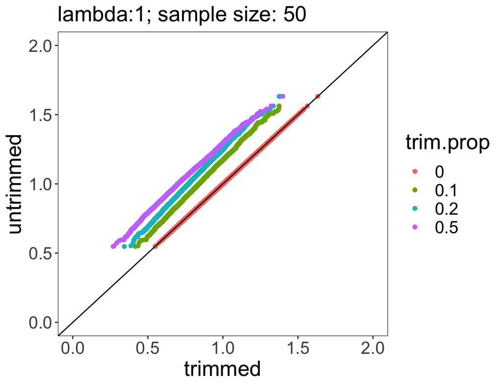

```r
plot(sim_results, type = "qq", lambda = 1, n = 50, ll = 0, ul = 2)
```

Similarly, the other setting of sample size can be used, such as small sample size `n = 5`,

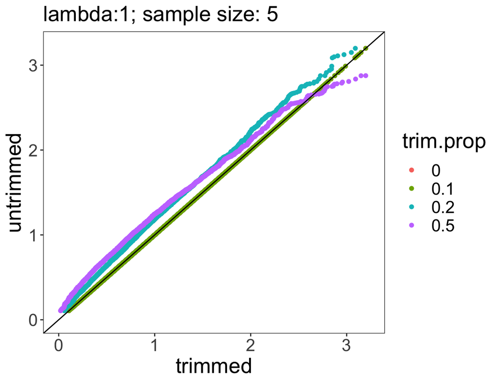

```r
plot(sim_results, type = "qq", lambda = 1, n = 5)
```

### Line plot

In the line plot, we set the level of $\lambda$ and visualize the performance measure varring by sample size and proportion of trimming.

#### Bias

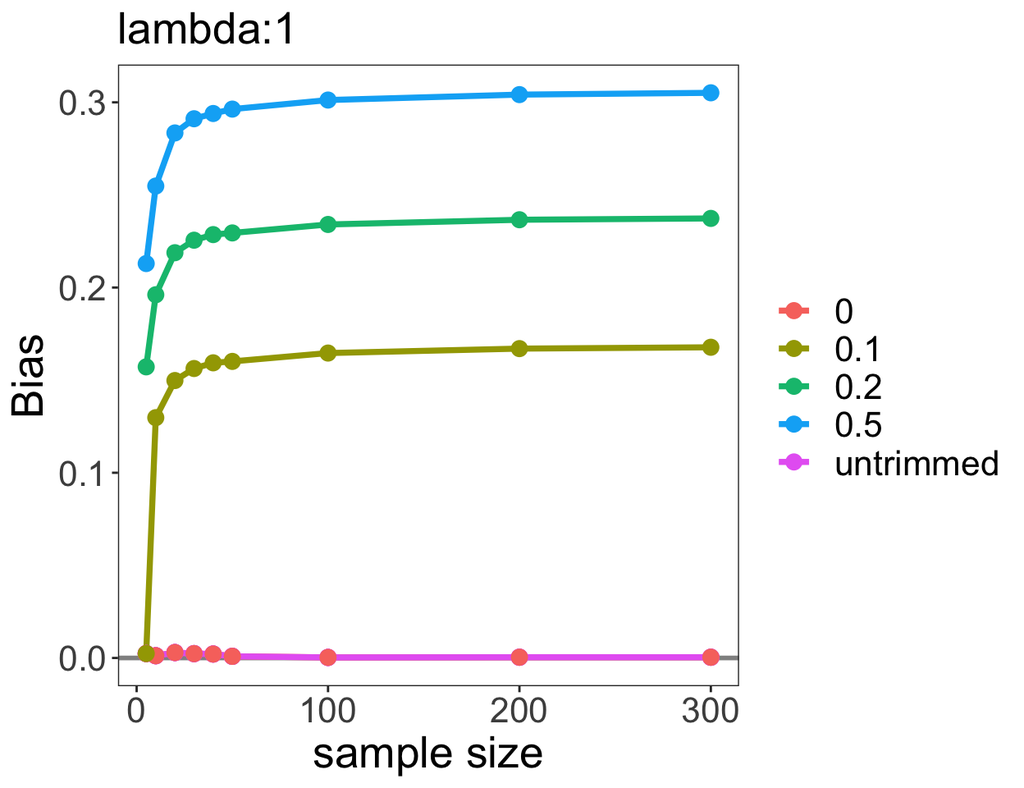

```r
plot(sim_results, type = "Bias", lambda = 1)
```

#### Standard Error (SE)

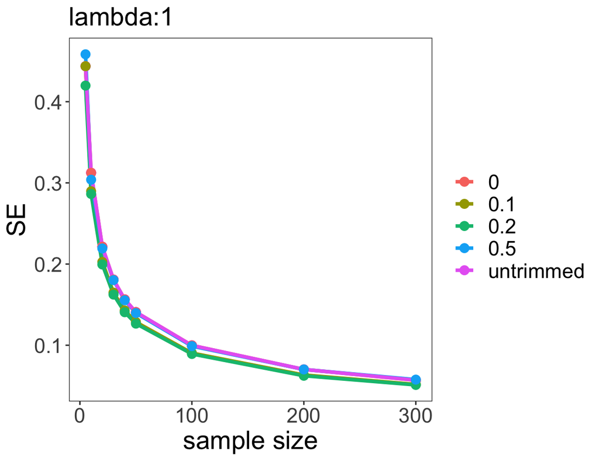

```r
plot(sim_results, type = "SE", lambda = 1)
```

#### Mean Square Error (MSE)

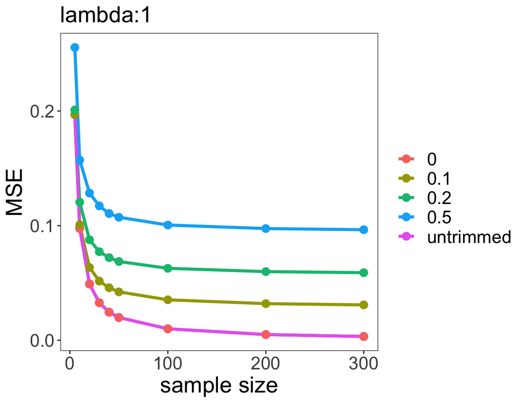

```r
plot(sim_results, type = "MSE", lambda = 1)
```

The functions described above are the core functions in `SimulationStudy` package. For more information, you could use `?` for the name of function to check the manual page.

# References

Chikkagoudar, M., and Kunchur, S. (1980), “Estimation of the mean of an exponential distribution in the presence of an outlier,” *Canadian Journal of Statistics*, Wiley Online Library, 8, 59–63.

Kimber, A. (1983), “Comparison of some robust estimators of scale in gamma samples with known shape,” *Journal of Statistical Computation and simulation*, Taylor & Francis, 18, 273–286.

Morris, T. P., White, I. R., and Crowther, M. J. (2019), “Using simulation studies to evaluate statistical methods,” *Statistics in medicine*, Wiley Online Library, 38, 2074–2102.

Willemain, T. R., Allahverdi, A., Desautels, P., ldredge, J., Gur, O., Panos, G., rinivasan, A., Surtihadi, J., Topal, E., and Miller, M. (1992), “Robust estimation methods for exponential data: A monte-carlo comparison,” *Communications in Statistics-Simulation and Computation*, Taylor & Francis, 21, 1043–1075.